# Analisi Preliminare degli Item

### 1.5.1 Passo 6: Matrice di correlazione

La matrice di correlazione tra gli item è uno strumento fondamentale per esplorare la struttura interna di una scala. L’idea di fondo è semplice: item che misurano lo stesso costrutto dovrebbero essere **positivamente correlati** tra loro.

#### 1.5.1.1 Quale coefficiente usare?

La scelta del coefficiente dipende dal numero di categorie di risposta $k$:

| Tipo di item | Coefficiente appropriato |
| --- | --- |
| Item dicotomici ($k$ = 2) | Correlazione tetracorica |
| Item Likert con $k \leq 4$ | Correlazione policorica |
| Item Likert con $k$ = 5 o più | Pearson (leggera distorsione) o policorica |

La correlazione di Pearson assume che i dati siano su scala continua e distribuiti normalmente. Gli item Likert sono ordinali: applicare Pearson introduce una certa distorsione, più evidente quando $k \leq 4$ o le distribuzioni sono molto asimmetriche.

Dopo la ricodifica, **tutte le correlazioni tra item della stessa scala dovrebbero essere positive**. Se ne persistono di negative, significa che qualche item reverse non è stato ricodificato.

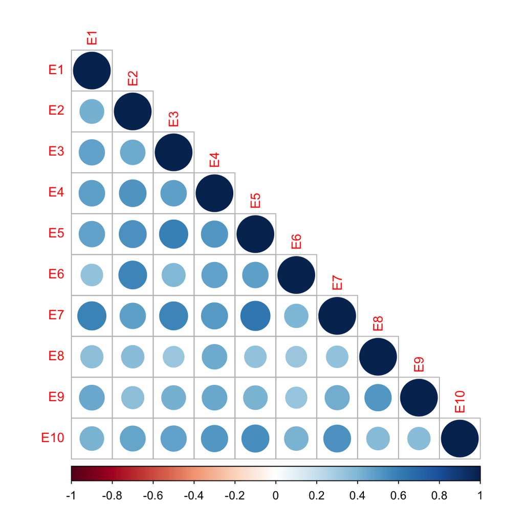

Matrice di correlazione – Estroversione (dopo la ricodifica)

```r
R_E <- cor(itemE, use = "pairwise.complete.obs") #escludo NA
corrplot(R_E, type = "lower", tl.cex = 0.9, mar = c(0, 0, 1, 0))
```

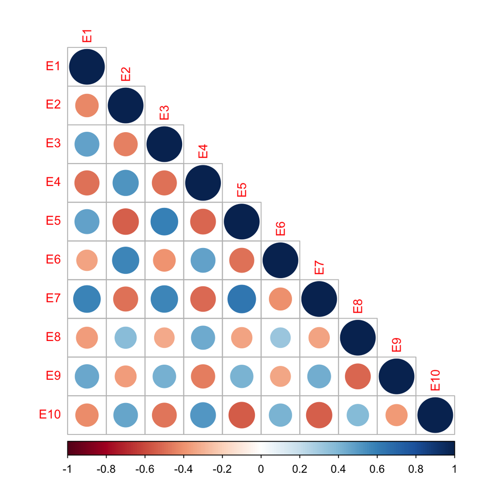

Matrice di correlazione – Estroversione (prima della ricodifica)

```r
R_E <- cor(itemE_orig, use = "pairwise.complete.obs") #escludo NA
corrplot(R_E, type = "lower", tl.cex = 0.9, mar = c(0, 0, 1, 0))
```

#### 1.5.1.2 **Correlazioni policoriche**

```r
polychoric(itemE)
```

```
Call: polychoric(x = itemE)
Polychoric correlations
    E1   E2   E3   E4   E5   E6   E7   E8   E9   E10
E1  1.00
E2  0.47 1.00
E3  0.53 0.50 1.00
E4  0.53 0.58 0.54 1.00
E5  0.54 0.60 0.65 0.57 1.00
E6  0.39 0.63 0.44 0.53 0.54 1.00
E7  0.65 0.54 0.65 0.56 0.70 0.46 1.00
E8  0.41 0.42 0.36 0.50 0.39 0.37 0.39 1.00
E9  0.51 0.41 0.47 0.50 0.47 0.38 0.49 0.58 1.00
E10 0.46 0.53 0.54 0.57 0.62 0.48 0.60 0.44 0.43 1.00

 with tau of
        1       2      3    4
E1  -0.72 -0.0890  0.654 1.44
E2  -1.15 -0.5060  0.109 0.79
E3  -1.39 -0.6826 -0.038 0.73
E4  -0.99 -0.2341  0.486 1.26
E5  -1.32 -0.6483 -0.082 0.67
E6  -1.41 -0.7567 -0.221 0.63
E7  -0.72 -0.1286  0.333 0.91
E8  -0.71 -0.0072  0.605 1.36
E9  -0.94 -0.3207  0.164 0.81
E10 -0.44  0.1940  0.713 1.39
```

La correlazione tra i punteggi degli item è positiva e moderata. Le soglie associate ad ogni categoria per ogni item sono riportate nella sezione with tau of..

### 1.5.2 Cosa sono le soglie $\tau$?

La correlazione policorica si basa sull’idea che la risposta Likert osservata $Y_i \in \{1, 2, 3, 4, 5\}$ non sia altro che la versione “tagliata” di una variabile latente continua $Y_i^*$, distribuita normalmente con media 0 e varianza 1. Questa variabile latente non è mai osservata direttamente: rappresenta il livello del tratto sottostante (es. estroversione) di ogni rispondente.

Le **soglie** $\tau$ sono i valori sulla scala di $Y_i^*$ che separano le categorie di risposta:

$$Y_i = k \quad \text{se} \quad \tau_{k-1} \leq Y_i^* < \tau_k,
\quad k = 1, \ldots, K$$

Con $K = 5$ categorie ci sono **4 soglie**: $\tau_1 < \tau_2 < \tau_3 < \tau_4$.

**Codice**

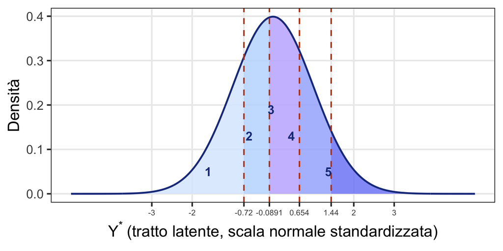

Variabile latente Y* e soglie τ per un item con scala 1–5. Ogni area colorata corrisponde a una categoria di risposta.

```r
# soglie stimate da polychoric() per E1
tau <- c(-0.72, -0.0891, 0.654, 1.44)

x <- seq(-5, 5, length.out = 1000)
df_curve <- data.frame(x = x, y = dnorm(x))

breaks <- c(-Inf, tau, Inf)
labels_cat <- paste("Risposta", 1:5)
colors <- c("#dbeafe", "#bfdbfe", "#c4b5fd", "#a5b4fc", "#818cf8")

df_areas <- do.call(rbind, lapply(1:5, function(k) {
  xs <- seq(max(-3.5, breaks[k]), min(3.5, breaks[k+1]), length.out = 200)
  data.frame(x = xs, y = dnorm(xs), categoria = labels_cat[k])
}))
df_areas$categoria <- factor(df_areas$categoria, levels = labels_cat)

df_tau <- data.frame(
  x   = tau,
  y   = dnorm(tau),
  lab = paste0("\u03c4", 1:4, " = ", tau)
)

ggplot() +
  geom_area(data = df_areas,
            aes(x = x, y = y, fill = categoria),
            position = "identity", alpha = 0.85) +
  geom_line(data = df_curve, aes(x = x, y = y),
            color = "#1e3a8a", linewidth = 1) +
  geom_vline(data = df_tau, aes(xintercept = x),
             color = "#C2410C", linetype = "dashed", linewidth = 0.8) +
  annotate("text",
           x = c(-1.6, -0.59, -0.045, 0.46, 1.37),
           y = c(0.05, 0.13, 0.19, 0.13, 0.05),
           label = 1:5,
           size = 5, fontface = "bold", color = "#1e3a8a") +
  scale_fill_manual(values = colors, name = NULL) +
  scale_x_continuous(breaks = c(-3, -2, tau, 2, 3),
                     labels = c("-3", "-2", as.character(tau), "2", "3")) +
  labs(
    x = expression(Y^"*" ~ "(tratto latente, scala normale standardizzata)"),
    y = "Densità"
  ) +
  theme_bw(base_size = 18) +
  theme(
    legend.position  = "none",
    panel.grid.minor = element_blank(),
    axis.text.x      = element_text(size = 9)
  )
```

**Come leggere i valori τ nell’output di R**

```r
polychoric(table(itemE$E1, itemE$E2))
# with tau of
#  E1  -0.72 -0.0891  0.654 1.44
#  E2  -1.15 -0.5059  0.109 0.79
```

Ogni riga riporta le 4 soglie di un item sulla scala normale standardizzata.

Come si vede nel grafico:

- **$\tau$ < 0**: la soglia è *sotto* la media
- **$\tau$ > 0**: la soglia è *sopra* la media
- La **distanza tra soglie consecutive** indica quanto è “larga” quella categoria: soglie vicine segnalano una categoria poco discriminante

```r
pnorm(-0.72)
```

```
[1] 0.2357625
```

### 1.5.3 Passo 7: Discriminatività

La **discriminatività** misura quanto un item riesce a distinguere persone con livelli alti da persone con livelli bassi del tratto. La misura standard è la **correlazione item-totale corretta**: la correlazione tra il punteggio all’item e il punteggio totale della scala calcolato *escludendo* quell’item dal totale.

Si dice “corretta” perché se includessimo l’item nel totale la correlazione sarebbe artificialmente gonfiata: un numero è sempre correlato con una somma di cui fa parte.

Assume che il tratto misurato sia unidimensionale, e dipende dal campione. Maggiore è l’eterogeneità dei livelli di abilità delle persone, maggiore è la capacità discriminatività degli item.

```r
alpha_E <- psych::alpha(itemE)
round(alpha_E$item.stats[, c("r.cor", "r.drop")], 2)
```

```
    r.cor r.drop
E1   0.66   0.63
E2   0.69   0.65
E3   0.69   0.65
E4   0.72   0.68
E5   0.76   0.71
E6   0.61   0.57
E7   0.75   0.70
E8   0.56   0.52
E9   0.62   0.58
E10  0.67   0.64
```

Se un item ha una correlazione item-totale corretta bassa o negativa, significa che non “lavora” nella stessa direzione del test e, quindi, discrimina male il costrutto.

```r
alpha_E <- psych::alpha(itemE_orig)
```

```
Some items ( E2 E4 E6 E8 E10 ) were negatively correlated with the first principal component and
probably should be reversed.
To do this, run the function again with the 'check.keys=TRUE' option
```

```r
round(alpha_E$item.stats[, c("r.cor", "r.drop")], 2)
```

```
    r.cor r.drop
E1   0.29   0.03
E2   0.11  -0.15
E3   0.30   0.02
E4   0.00  -0.19
E5   0.18  -0.08
E6   0.16  -0.09
E7   0.38  -0.01
E8  -0.02  -0.16
E9   0.06  -0.10
E10 -0.11  -0.24
```

### 1.5.4 Passo 8: Ridondanza

Due item sono **ridondanti** se correlano troppo tra loro ($r > .70$): stanno misurando sostanzialmente la stessa cosa e uno dei due potrebbe essere rimosso senza perdita di informazione rilevante.

```r
# estraggo il triangolo superiore e ordino per correlazione decrescente
corr_E <- data.frame(
  item1 = rownames(R_E)[row(R_E)[upper.tri(R_E)]],
  item2 = colnames(R_E)[col(R_E)[upper.tri(R_E)]],
  r     = round(R_E[upper.tri(R_E)], 2)
)
corr_E <- corr_E[order(-corr_E$r), ]
head(corr_E, 10)
```

```
   item1 item2    r
20    E5    E7 0.63
9     E3    E5 0.59
16    E1    E7 0.59
18    E3    E7 0.58
12    E2    E6 0.57
5     E2    E4 0.53
40    E4   E10 0.51
7     E1    E5 0.48
14    E4    E6 0.48
2     E1    E3 0.47
```

## 1.6 Appendice: struttura dell’intero questionario

Prima di passare all’esercizio, visualizziamo la matrice di correlazione dell’intero questionario dopo aver ricodificato **tutti** gli item reverse. Questo ci permette di apprezzare la struttura a blocchi del Big Five.

**Codice**

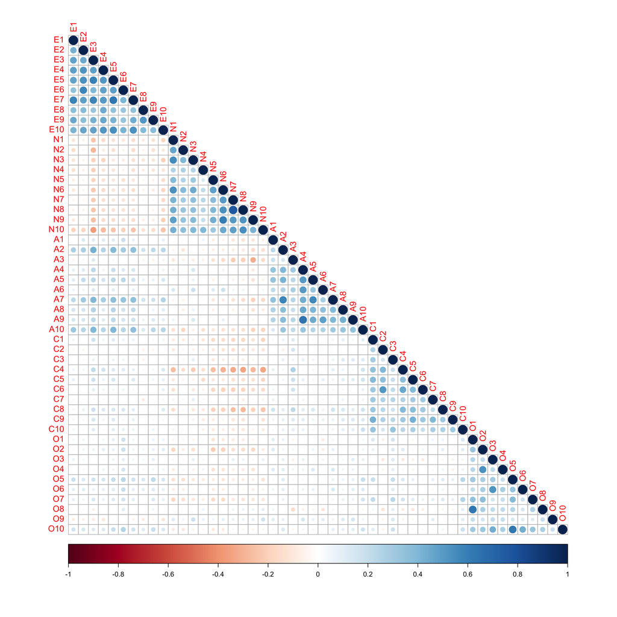

Matrice di correlazione dell’intero questionario (tutti gli item reverse ricodificati, ordinati per scala)

```r
# item reverse per tutte le scale
rev_E <- paste("E", seq(2, 10, by = 2), sep = "")
rev_N <- c("N2", "N4")
rev_A <- c("A1", "A3", "A5", "A7")
rev_C <- c("C2", "C4", "C6", "C8")
rev_O <- c("O2", "O4", "O6")
tutti_rev <- c(rev_E, rev_N, rev_A, rev_C, rev_O)

item_rec <- item
item_rec[, tutti_rev] <- 6 - item_rec[, tutti_rev]

# ordino le colonne per scala
ordine <- c(paste("E", 1:10, sep = ""), paste("N", 1:10, sep = ""),
            paste("A", 1:10, sep = ""), paste("C", 1:10, sep = ""),
            paste("O", 1:10, sep = ""))

R_rec <- cor(item_rec[, ordine], use = "pairwise.complete.obs")
corrplot(R_rec, type = "lower", tl.cex = 1, mar = c(0, 0, 1, 0))
```

**Esercizio: Nevroticismo**

Applica la stessa procedura alla scala di **Nevroticismo** (item reverse: N2, N4):

1. Estrai gli item N1–N10
2. Analizza i dati mancanti
3. Ricodifica N2 e N4 con la formula $6 - x$
4. Calcola statistiche descrittive e $p_i^*$
5. Visualizza la distribuzione delle risposte con `ggplot2`
6. Calcola e visualizza la matrice di correlazione
7. Valuta la discriminatività con `alpha()`
8. Verifica se ci sono coppie di item ridondanti ($r > .70$)